# Cyclistic_bike_share_analysis

Sudharshan

2024-01-14

## The ask phase

**The ask phase of the case study focuses on**

- The problem statement
- Effect of your insight on business decision
- Business task
- Stakeholders

**Business task**

Conduct data analysis to identify the difference between how casual riders and annual members use the bike

**Stakeholder analysis**

- Responsible: Sudharsana Prasad
- Consult: Marketing team
- Accountable: Lily Moreno
- Inform: Executives

## Prepare

**Date location**

**Data cleaning and inspection**

The first step is to read all the datasets into R

```r
#install.packages("tidyverse", repos = "http://cran.us.r-project.org")
#install.packages("skimr", repos = "http://cran.us.r-project.org")
#install.packages("DescTools", repos = "http://cran.us.r-project.org")
#install.packages("dplyr", repos = "http://cran.us.r-project.org")
#install.packages("ggplot2", repos = "http://cran.us.r-project.org")
library(tidyverse)
library(skimr)
library(DescTools)
library(dplyr)
library(ggplot2)
```

```r
parent_dir <- "D:\\DA tutorial\\Case studies\\Cyclistic data sources\\trip_data_2023\\"
for(i in 202301:202312){
  file_name <- paste0(parent_dir, i, "-divvy-tripdata\\", i, "-divvy-tripdata.csv")
  assign(paste0("trip_", i), read_csv(file_name))
}
```

**Inspecting data** The trip data is stored in 12 different tables, each table for every month in 2023. The tables are read into 12 different data frames from trip_202301 to trip_202312.  
There are totally 13 columns and three different data types (Character, Double and Date time). The data frames are now combined into a single data frame trips_2023

```r
trips_2023 <- rbind(trip_202301, trip_202302, trip_202303, trip_202304, trip_202305, trip_202306, trip_202307, trip_202308, trip_202309, trip_202310, trip_202311, trip_202312)
```

## Process

Calculating how long the rides were for each ride in 2023.

```r
trips_2023 <- mutate(trips_2023, ride_length = trips_2023$ended_at - trips_2023$started_at)
str(trips_2023)
```

```
## tibble [5,719,877 × 14] (S3: tbl_df/tbl/data.frame)
##  $ ride_id           : chr [1:5719877] "F96D5A74A3E41399" "13CB7EB698CEDB88" "BD88A2E670661CE5" "C90792D034FED968" ...
##  $ rideable_type     : chr [1:5719877] "electric_bike" "classic_bike" "electric_bike" "classic_bike" ...
##  $ started_at        : POSIXct[1:5719877], format: "2023-01-21 20:05:42" "2023-01-10 15:37:36" ...
##  $ ended_at          : POSIXct[1:5719877], format: "2023-01-21 20:16:33" "2023-01-10 15:46:05" ...
##  $ start_station_name: chr [1:5719877] "Lincoln Ave & Fullerton Ave" "Kimbark Ave & 53rd St" "Western Ave & Lunt Ave" "Kimbark Ave & 53rd St" ...
##  $ start_station_id  : chr [1:5719877] "TA1309000058" "TA1309000037" "RP-005" "TA1309000037" ...
##  $ end_station_name  : chr [1:5719877] "Hampden Ct & Diversey Ave" "Greenwood Ave & 47th St" "Valli Produce - Evanston Plaza" "Greenwood Ave & 47th St" ...
##  $ end_station_id    : chr [1:5719877] "202480.0" "TA1308000002" "599" "TA1308000002" ...
##  $ start_lat         : num [1:5719877] 41.9 41.8 42 41.8 41.8 ...
##  $ start_lng         : num [1:5719877] -87.6 -87.6 -87.7 -87.6 -87.6 ...
##  $ end_lat           : num [1:5719877] 41.9 41.8 42 41.8 41.8 ...
##  $ end_lng           : num [1:5719877] -87.6 -87.6 -87.7 -87.6 -87.6 ...
##  $ member_casual     : chr [1:5719877] "member" "member" "casual" "member" ...
##  $ ride_length       : 'difftime' num [1:5719877] 651 509 794 526 ...
##   ..- attr(*, "units")= chr "secs"
```

Creating a column of day_of_week and removing incomplete observations

```r
trips_2023 <- mutate(trips_2023, day_of_week = weekdays(trips_2023$started_at))
str(trips_2023)
```

```
## tibble [5,719,877 × 15] (S3: tbl_df/tbl/data.frame)
##  $ ride_id           : chr [1:5719877] "F96D5A74A3E41399" "13CB7EB698CEDB88" "BD88A2E670661CE5" "C90792D034FED968" ...
##  $ rideable_type     : chr [1:5719877] "electric_bike" "classic_bike" "electric_bike" "classic_bike" ...
##  $ started_at        : POSIXct[1:5719877], format: "2023-01-21 20:05:42" "2023-01-10 15:37:36" ...
##  $ ended_at          : POSIXct[1:5719877], format: "2023-01-21 20:16:33" "2023-01-10 15:46:05" ...
##  $ start_station_name: chr [1:5719877] "Lincoln Ave & Fullerton Ave" "Kimbark Ave & 53rd St" "Western Ave & Lunt Ave" "Kimbark Ave & 53rd St" ...
##  $ start_station_id  : chr [1:5719877] "TA1309000058" "TA1309000037" "RP-005" "TA1309000037" ...
##  $ end_station_name  : chr [1:5719877] "Hampden Ct & Diversey Ave" "Greenwood Ave & 47th St" "Valli Produce - Evanston Plaza" "Greenwood Ave & 47th St" ...
##  $ end_station_id    : chr [1:5719877] "202480.0" "TA1308000002" "599" "TA1308000002" ...
##  $ start_lat         : num [1:5719877] 41.9 41.8 42 41.8 41.8 ...
##  $ start_lng         : num [1:5719877] -87.6 -87.6 -87.7 -87.6 -87.6 ...
##  $ end_lat           : num [1:5719877] 41.9 41.8 42 41.8 41.8 ...
##  $ end_lng           : num [1:5719877] -87.6 -87.6 -87.7 -87.6 -87.6 ...
##  $ member_casual     : chr [1:5719877] "member" "member" "casual" "member" ...
##  $ ride_length       : 'difftime' num [1:5719877] 651 509 794 526 ...
##   ..- attr(*, "units")= chr "secs"
##  $ day_of_week       : chr [1:5719877] "Saturday" "Tuesday" "Monday" "Sunday" ...
```

```r
trips_2023 <- na.omit(trips_2023)
```

Arranging the data frame in ascending order of started_at column

```r
trips_2023 <- arrange(trips_2023, started_at)
```

## Analyze

Calculating mean, and max of ride_length

```r
mean(trips_2023$ride_length)
```

```
## Time difference of 957.1109 secs
```

```r
max(trips_2023$ride_length)
```

```
## Time difference of 728178 secs
```

Calculating the Mode of day_of_week

```r
Mode(trips_2023$day_of_week) # Package used DescTools
```

```
## [1] "Saturday"
## attr(,"freq")
## [1] 660811
```

### Calculations

Calculate the average ride_length for members and casual riders for each month

```r
trips_2023 %>%
  group_by(month(started_at), member_casual) %>%
  summarise(mean(ride_length))
```

```
## # A tibble: 24 × 3
## # Groups:   month(started_at) [12]
##    `month(started_at)` member_casual `mean(ride_length)`
##                  <dbl> <chr>         <drtn>
##  1                   1 casual         892.7328 secs
##  2                   1 member         600.2687 secs
##  3                   2 casual        1060.3380 secs
##  4                   2 member         625.3198 secs
##  5                   3 casual        1003.1506 secs
##  6                   3 member         610.2521 secs
##  7                   4 casual        1357.2393 secs
##  8                   4 member         693.3512 secs
##  9                   5 casual        1471.4685 secs
## 10                   5 member         761.6204 secs
## # ℹ 14 more rows
```

Calculate the average ride_length for users by day_of_week.

```r
trips_2023 %>%
  group_by(month(started_at), member_casual, day_of_week) %>%
  summarize(mean(ride_length))
```

[output not shown]

```
## # A tibble: 168 × 4
## # Groups:   month(started_at), member_casual [24]
##    `month(started_at)` member_casual day_of_week `mean(ride_length)`
##                  <dbl> <chr>         <chr>       <drtn>
##  1                   1 casual        Friday       739.4646 secs
##  2                   1 casual        Monday       864.5407 secs
##  3                   1 casual        Saturday     991.8483 secs
##  4                   1 casual        Sunday      1197.0056 secs
##  5                   1 casual        Thursday     721.5779 secs
##  6                   1 casual        Tuesday      833.1263 secs
##  7                   1 casual        Wednesday    838.7218 secs
##  8                   1 member        Friday       607.8049 secs
##  9                   1 member        Monday       579.1467 secs
## 10                   1 member        Saturday     624.5106 secs
## # ℹ 158 more rows
```

```r
rides_table <- trips_2023 %>%
  group_by(month(started_at), member_casual) %>%
  count(member_casual)
colnames(rides_table) <- c('month', 'member_type', 'num_of_rides')
tibble(rides_table)
```

```
## # A tibble: 24 × 3
##    month member_type num_of_rides
##    <dbl> <chr>              <int>
##  1     1 casual             29621
##  2     1 member            118663
##  3     2 casual             32776
##  4     2 member            116784
##  5     3 casual             46792
##  6     3 member            153655
##  7     4 casual            110538
##  8     4 member            213659
##  9     5 casual            177039
## 10     5 member            286188
## # ℹ 14 more rows
```

## Share

### Visualization

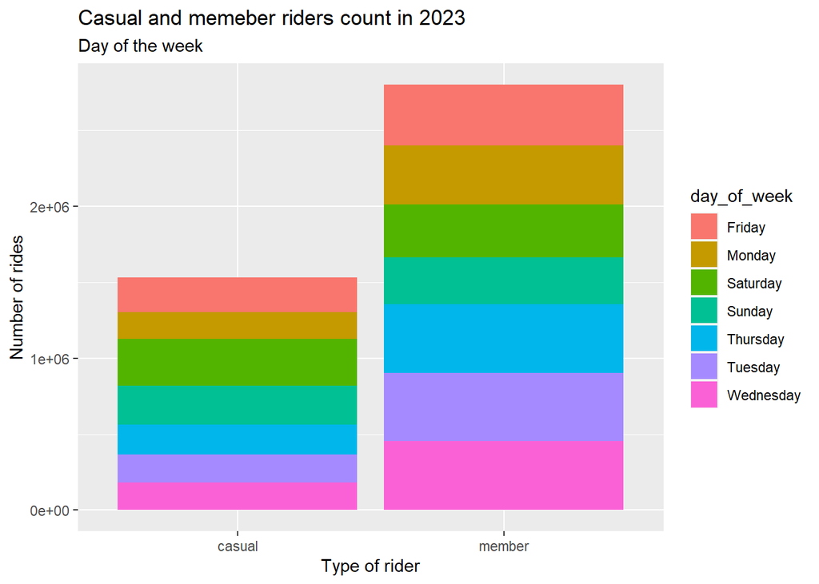

```r
ggplot(trips_2023) +
  geom_bar(mapping = aes(x = member_casual, fill = day_of_week)) +
  labs(title = "Casual and memeber riders count in 2023", subtitle = "Day of the week", x = "Type of rider", y = "Number of rides")
```

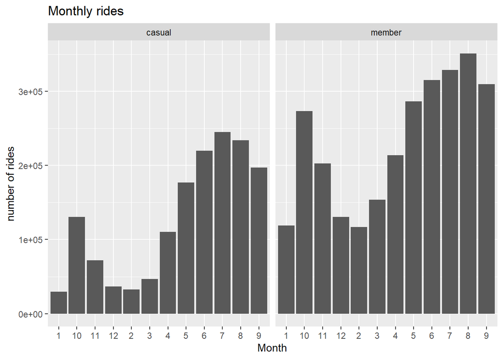

```r
trips_2023 %>% ggplot(aes(x = fct_relevel(as.character(month(started_at), c("10", "11", "12"), after = 12)))) +
  geom_bar() +
  facet_wrap(~member_casual) +
  labs(title = "Monthly rides", x = "Month", y = "number of rides" )
```